# 1_Descriptive Statistics and Linear Regression_Dipal Nagda

### Loading the data:

```r
library(dplyr)
library(tidyr)
library(tidyverse)
```

```r
library(ggplot2)
library(ggpubr)
library(tidyverse)

t1 <- read.csv("data1.csv")

# Select specific variables and filter in only OECD countries
OECD_label <- c("Australia", "Austria", "Belgium", "Canada", "Chile", "Colombia", "Costa Rica", "Czech Republic", "Denmark", "Estonia", "Finland", "France", "Germany", "Greece", "Hungary", "Iceland", "Ireland", "Israel", "Italy", "Japan", "Korea", "Latvia", "Lithuania", "Luxembourg", "Mexico", "Netherlands", "New Zealand", "Norway", "Poland", "Portugal", "Slovak Republic", "Slovenia", "Spain", "Sweden", "Switzerland", "Turkey", "United Kingdom", "United States")

t1 <- t1 %>%
  dplyr::select(Country, IND, Indicator, Sex, Age.Group, Time, Value, Unit, Flags) %>%
  filter (Country %in% OECD_label)
```

Creating a df with the variables of interest:

```r
# Isolate variables of interest
# Removing the age group variable (and filtering for total age group when appropriate)
# In order to merge into one dataframe, time variable was isolated only to 2018 for most variables as that is the most recent year with the most complete data.

DN_t1 <- t1 %>%
  filter(Time %in% c("Latest year", "2018"))

#*** Time for the unpaid, paid and total time is "Latest Year"
unpaid_time <- DN_t1 %>%
  filter(Indicator == "Time spent in unpaid work, by sex") %>%
  dplyr::select(Country, Sex, Value) %>%
  rename(unpaid_time = Value)

paid_time <- DN_t1 %>%
  filter(Indicator == "Time spent in paid work, by sex") %>%
  dplyr::select(Country, Sex, Value) %>%
  rename(paid_time = Value)

total_time <- DN_t1 %>%
  filter(Indicator == "Time spent in total work, by sex") %>%
  dplyr::select(Country, Sex, Value) %>%
  rename(total_time = Value)

agriculture_work <- DN_t1 %>%
  filter(Indicator == "Share of employed working in agriculture, by sex") %>%
  dplyr::select(Country, Sex, Value) %>%
  rename(agriculture_work = Value)

industry_work <- DN_t1 %>%
  filter(Indicator == "Share of employed working in industry, by sex") %>%
  dplyr::select(Country, Sex, Value) %>%
  rename(industry_work = Value)

services_work <- DN_t1 %>%
  filter(Indicator == "Share of employed working in services, by sex") %>%
  dplyr::select(Country, Sex, Value) %>%
  rename(services_work = Value)

maternity_leave <- DN_t1 %>%
  filter(Indicator == "Length of maternity leave") %>%
  dplyr::select(Country, Sex, Value) %>%
  rename(maternity_leave = Value)

leave_job_protection <- DN_t1 %>%
  filter(Indicator == "Length of parental leave with job protection") %>%
  dplyr::select(Country, Sex, Value) %>%
  rename(leave_job_protection = Value)

total_paid_leave <- DN_t1 %>%
  filter(Indicator == "Total length of paid maternity and parental leave") %>%
  dplyr::select(Country, Sex, Value) %>%
  rename(total_paid_leave = Value)

paternal_leave <- DN_t1 %>%
  filter(Indicator == "Length of paid father-specific leave") %>%
  dplyr::select(Country, Sex, Value) %>%
  rename(paternal_leave = Value)

share_managers <- DN_t1 %>%
  filter(Indicator == "Share of employed who are managers, by sex") %>%
  dplyr::select(Country, Sex, Value) %>%
  rename(share_managers = Value)

female_share_boards <- DN_t1 %>%
  filter(Indicator == "Female share of seats on boards of the largest publicly listed companies") %>%
  dplyr::select(Country, Sex, Value) %>%
  rename(female_share_boards = Value)

share_involuntary_parttime <- DN_t1 %>%
  filter(Indicator == "Share of employed in involuntary part-time employment, by sex and age group",
         Age.Group=="Total") %>%
  dplyr::select(Country, Sex, Value) %>%
  rename(share_involunttary_parttime = Value)

share_parttime <- DN_t1 %>%
  filter(Indicator == "Share of employed in part-time employment, by sex and age group",
         Age.Group=="Total") %>%
  dplyr::select(Country, Sex, Value) %>%
  rename(share_parttime = Value)

# Create new dataframe
data_list <- list(unpaid_time, paid_time, total_time, agriculture_work, industry_work, services_work, maternity_leave, leave_job_protection, total_paid_leave, paternal_leave, share_managers, female_share_boards, share_involuntary_parttime, share_parttime)

new_data <- data_list %>%
  reduce(left_join, by=c("Country", "Sex"))
```

A new ratio variable was created to standardize the proportion of total labor that is unpaid for both men and women:

```r
new_data <- new_data %>%
  mutate(prop_unpaid = unpaid_time/total_time)
```

### Descriptive Statistics of Labor by Sex

Average time in unpaid labor by sex (minutes/day)

```r
new_data %>%
  group_by(Sex) %>%
  summarize_at(vars(unpaid_time), list(Average_Time_Unpaid = mean, Standard_Deviation = sd))
```

```
## # A tibble: 2 × 3
##   Sex   Average_Time_Unpaid Standard_Deviation
##   <chr>               <dbl>              <dbl>
## 1 Men                  136.               35.2
## 2 Women                263.               34.5
```

```r
# Independent two-sample t-test on these differences
t.test(new_data$unpaid_time[new_data$Sex=="Women"], new_data$unpaid_time[new_data$Sex=="Men"])
```

```
##
##  Welch Two Sample t-test
##
## data:  new_data$unpaid_time[new_data$Sex == "Women"] and new_data$unpaid_time[new_data$Sex == "Men"]
## t = 14.099, df = 57.977, p-value < 2.2e-16
## alternative hypothesis: true difference in means is not equal to 0
## 95 percent confidence interval:
##  108.9379 144.9888
## sample estimates:
## mean of x mean of y
##  263.4267  136.4633
```

Average time spent in paid labor by sex (minutes/day)

```r
new_data %>%
  group_by(Sex) %>%
  summarize_at(vars(paid_time), list(Average_Time_Paid = mean, Standard_Deviation = sd))
```

```
## # A tibble: 2 × 3
##   Sex   Average_Time_Paid Standard_Deviation
##   <chr>             <dbl>              <dbl>
## 1 Men                318.               62.0
## 2 Women              218.               40.9
```

```r
t.test(new_data$paid_time[new_data$Sex=="Women"], new_data$paid_time[new_data$Sex=="Men"])
```

```
##
##  Welch Two Sample t-test
##
## data:  new_data$paid_time[new_data$Sex == "Women"] and new_data$paid_time[new_data$Sex == "Men"]
## t = -7.3824, df = 50.268, p-value = 1.471e-09
## alternative hypothesis: true difference in means is not equal to 0
## 95 percent confidence interval:
##  -127.31812  -72.86188
## sample estimates:
## mean of x mean of y
##  217.7233  317.8133
```

Average proportion of time unpaid by sex

```r
new_data %>%
  group_by(Sex) %>%
  summarize_at(vars(prop_unpaid), list(Average_Proportion_Unpaid = mean, Standard_Deviation = sd))
```

```
## # A tibble: 2 × 3
##   Sex   Average_Proportion_Unpaid Standard_Deviation
##   <chr>                     <dbl>              <dbl>
## 1 Men                       0.304             0.0830
## 2 Women                     0.549             0.0658
```

```r
t.test(new_data$prop_unpaid[new_data$Sex=="Women"], new_data$prop_unpaid[new_data$Sex=="Men"])
```

```
##
##  Welch Two Sample t-test
##
## data:  new_data$prop_unpaid[new_data$Sex == "Women"] and new_data$prop_unpaid[new_data$Sex == "Men"]
## t = 12.676, df = 55.124, p-value < 2.2e-16
## alternative hypothesis: true difference in means is not equal to 0
## 95 percent confidence interval:
##  0.2063182 0.2838037
## sample estimates:
## mean of x mean of y
## 0.5489481 0.3038871
```

As the above statistics demonstrate, in the OECD countries, women work unpaid on average 263 minutes/day while men work unpaid for 136 minutes/day. This difference is statistically significant. Men work more minutes on average for paid labor than women (318 versus 218 minutes/day), a result that is also statistically significant. Finally the proportion of unpaid labor to total labor variable demonstrates that women spend a significantly larger proportion of their total labor in unpaid labor compared to men (0.55 versus 0.30).

### Graphical Visualizations of Time Differences in Unpaid Labor by Country

The OECD countries vary in their labor differences by sex. To graphically visualize this phenomenon, the percent of time unspent per country was graphed using a bar chart.

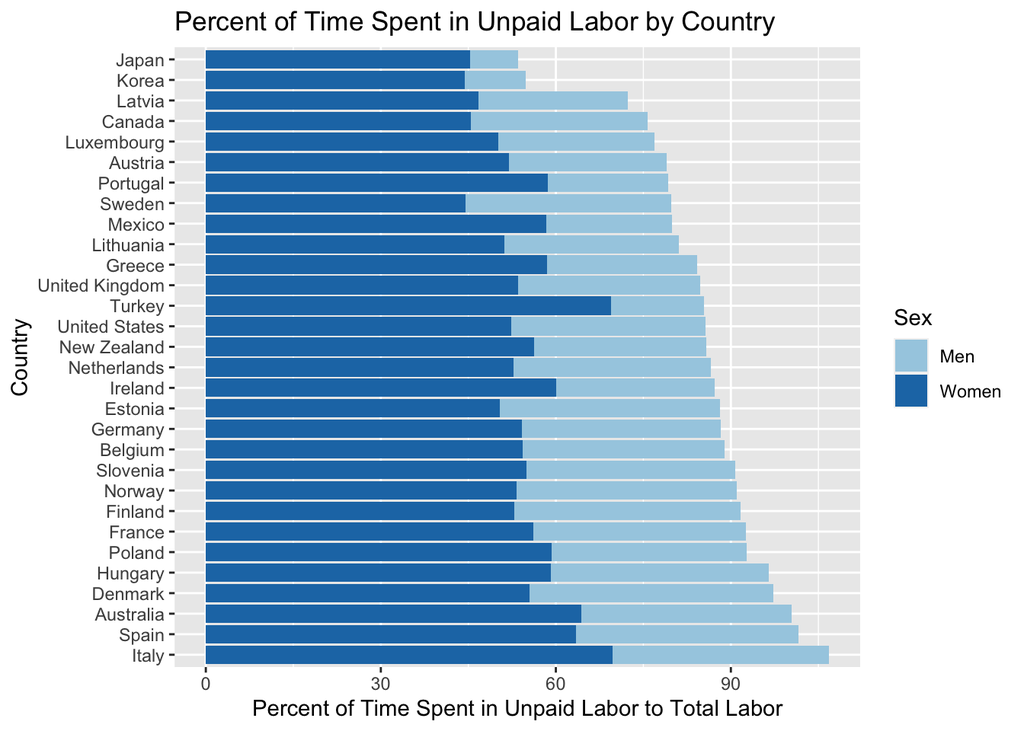

```r
new_data %>%
  ggplot(aes(x=reorder(Country, -prop_unpaid), y=(prop_unpaid*100), fill=Sex)) +
  geom_bar(stat="identity") +
  scale_fill_brewer(palette="Paired") +
  coord_flip() +
  labs(x="Country", y="Percent of Time Spent in Unpaid Labor to Total Labor", title="Percent of Time Spent in Unpaid Labor by Country")
```

The OECD countries vary greatly with respect to the percent of time that men and women spend in unpaid labor. It is clear, however, that across all OECD countries, women spend more time than men in unpaid labor. To understand how the share of labor, and other variables related to labor force participation varies between continents, 1-2 countries per continent were selected and compared against each other.

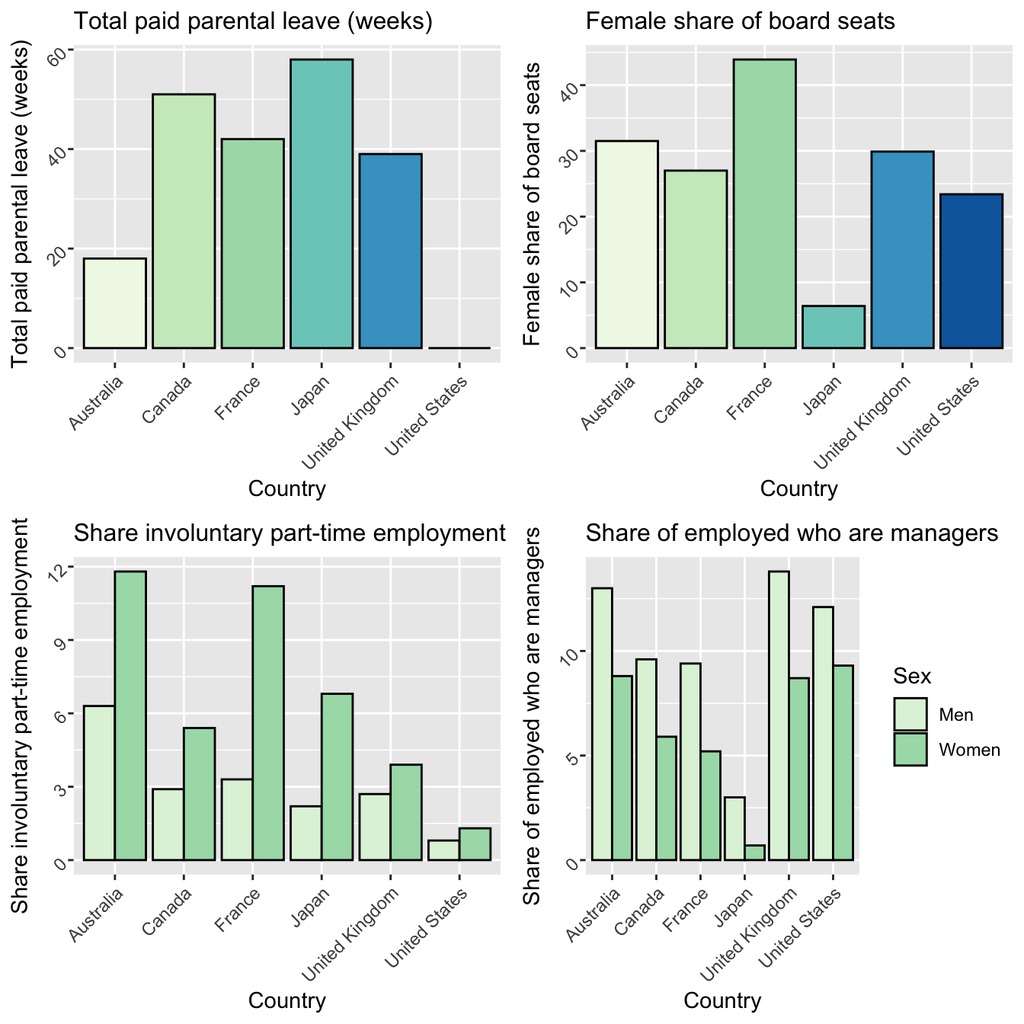

```r
total_paid <- new_data %>%
  filter(Country %in% c("Canada", "United States", "United Kingdom", "Japan", "Australia", "France")) %>%
  ggplot(aes(x=Country, y=total_paid_leave, fill=Country)) +
  scale_fill_brewer(palette="GnBu") +
  geom_bar(stat="identity", color="Black") +
  theme(legend.position = "none", axis.text=element_text(angle=45, hjust=1), plot.title=element_text(size=12)) +
  labs(x="Country", y="Total paid parental leave (weeks)", title="Total paid parental leave (weeks)")

female_share_boards <- new_data %>%
  filter(Country %in% c("Canada", "United States", "United Kingdom", "Japan", "Australia", "France")) %>%
  ggplot(aes(x=Country, y=female_share_boards, fill=Country)) +
  scale_fill_brewer(palette="GnBu") +
  geom_bar(stat="identity", color="Black", position=position_dodge()) +
  theme(legend.position="none", axis.text=element_text(angle=45, hjust=1), plot.title=element_text(size=12)) +
  labs(x="Country", y="Female share of board seats", title="Female share of board seats")

share_involuntary <- new_data %>%
  filter(Country %in% c("Canada", "United States", "United Kingdom", "Japan", "Australia", "France")) %>%
  ggplot(aes(x=Country, y=share_involunttary_parttime, fill=Sex)) +
  scale_fill_brewer(palette="GnBu") +
  geom_bar(stat="identity", color="Black", position=position_dodge()) +
  theme(legend.position = "none", axis.text=element_text(angle=45, hjust=1), plot.title=element_text(size=12)) +
  labs(x="Country", y="Share involuntary part-time employment", title="Share involuntary part-time employment")

share_managers <- new_data %>%
  filter(Country %in% c("Canada", "United States", "United Kingdom", "Japan", "Australia", "France")) %>%
  ggplot(aes(x=Country, y=share_managers, fill=Sex)) +
  scale_fill_brewer(palette="GnBu") +
  geom_bar(stat="identity", color="Black", position=position_dodge()) +
  theme(axis.text=element_text(angle=45, hjust=1), plot.title=element_text(size=12)) +
  labs(x="Country", y="Share of employed who are managers", title="Share of employed who are managers")

ggarrange(total_paid, female_share_boards, share_involuntary, share_managers, ncol=2, nrow=2)
```

### Scatter plots to assess linear correlation

To prepare for running a linear regression model to predict the percent of total labor that is unpaid, scatterplots were created to visualize the relationship between various continuous covariates. These graphs demonstrate that many of the covariates do not have a linear relationship with the outcome of proportion unpaid labor, thereby limiting the use of regression model.

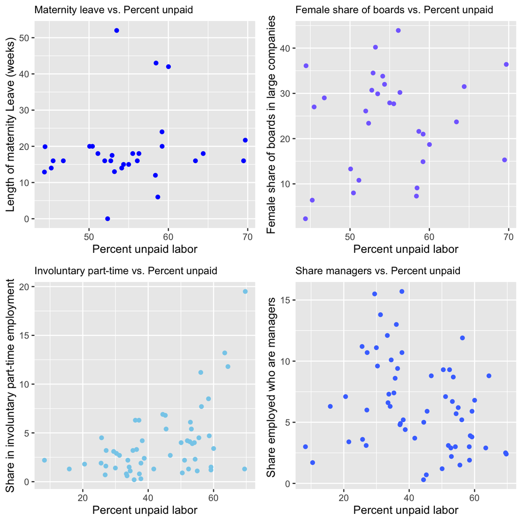

```r
maternity <- new_data %>%
  filter(Sex=="Women") %>%
  ggplot(aes(x=(prop_unpaid*100), y=maternity_leave)) +
  geom_point(color="Blue") +
  labs(x="Percent unpaid labor", y="Length of maternity Leave (weeks)", title="Maternity leave vs. Percent unpaid") +
  theme(plot.title=element_text(size=10))

share_involuntary <- new_data %>%
  ggplot(aes(x=(prop_unpaid*100), y=share_involunttary_parttime)) +
  geom_point(color="Sky Blue") +
  labs(x="Percent unpaid labor", y="Share in involuntary part-time employment", title="Involuntary part-time vs. Percent unpaid") +
  theme(plot.title=element_text(size=10))

share_managers <- new_data %>%
  ggplot(aes(x=(prop_unpaid*100), y=share_managers)) +
  geom_point(color="royalblue1") +
  labs(x="Percent unpaid labor", y="Share employed who are managers ", title="Share managers vs. Percent unpaid")+
  theme(plot.title=element_text(size=10))

female_boards <- new_data %>%
  filter(Sex=="Women") %>%
  ggplot(aes(x=(prop_unpaid*100), y=female_share_boards)) +
  geom_point(color="Slateblue1") +
  labs(x="Percent unpaid labor", y="Female share of boards in large companies", title="Female share of boards vs. Percent unpaid")+
  theme(plot.title=element_text(size=10))

ggarrange(maternity, female_boards, share_involuntary, share_managers, nrow=2, ncol=2)
```

These plots demonstrate that most covariates have a very weak linear relationship with the proportion of unpaid labor. Share of involuntary part-time employment visually appears to have the strongest linear relationship with proportion of unpaid labor.

### Linear Regression

We combined these various covariates into a linear regression model using our dataset to determine if any were significantly correlated to our outcome of interest (percent of unpaid labor out of total labor for women). Below are the results of our regression model:

```r
model.1 <- lm((prop_unpaid*100) ~ share_managers + female_share_boards + share_involunttary_parttime + total_time + maternity_leave + total_paid_leave + share_parttime,
              data=subset(new_data, Sex=="Women"))

broom::tidy(model.1)
```

```
## # A tibble: 8 × 5
##   term                        estimate std.error statistic  p.value
##   <chr>                          <dbl>     <dbl>     <dbl>    <dbl>
## 1 (Intercept)                  91.8      21.8        4.21  0.000433
## 2 share_managers                0.108     0.467      0.232 0.819
## 3 female_share_boards          -0.127     0.157     -0.808 0.429
## 4 share_involunttary_parttime   0.533     0.320      1.66  0.112
## 5 total_time                   -0.0632    0.0387    -1.63  0.118
## 6 maternity_leave               0.0392    0.124      0.317 0.755
## 7 total_paid_leave             -0.0485    0.0302    -1.61  0.123
## 8 share_parttime               -0.200     0.121     -1.66  0.113
```

The results of our linear regression model show, as expected, that many of our included covariates are not significant predictors of the outcome of percent unpaid labor amongst women. We hypothesize that several important predictors (such as education, poverty, GDP, important industries) have not been included in this regression model. It is interesting to note, however, the direction of the beta coefficients for some of the variables. For instance, the share of female board seats in large publicly-traded companies has a negative coefficient - a higher share of female board seats is associated with lower percent unpaid labor. Similarly, as the share of involuntary part-time labor amongst women increases, the proportion of unpaid labor also increases. These general trends align with our original hypothesis that increased economic and political representation of women may correlate with lower share of unpaid labor.